# Cyfrowe przetwarzanie sygnałów i obrazów

**Autorki:** Barbara Parzonka 263955, Joanna Zoglowek 264452  
**Ćwiczenie 9.**  
Zbadaj skuteczność redukcji szumu typu „sól i pieprz” za pomocą  
a) liniowego filtra uśredniającego z kwadratową maską, rozpoczynając od maski rozmiaru 3 × 3.  
b) nieliniowego filtra medianowego  
c) filtrów minimum i maksimum.  
**Dane:**cboard_pepper_only.tif, cboard_salt_only.tif, cboard_salt_pepper.tif  
Wykonaj eksperymenty dla różnych rozmiarów masek i wyciągnij wnioski.

```
cboard_pepper_only
```

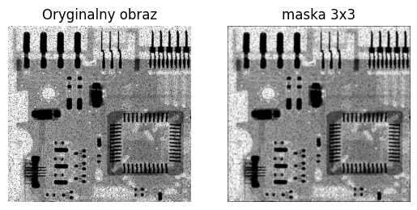

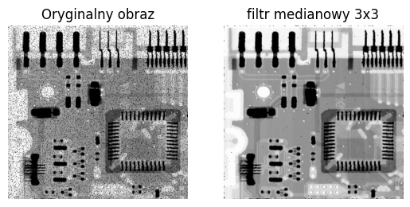

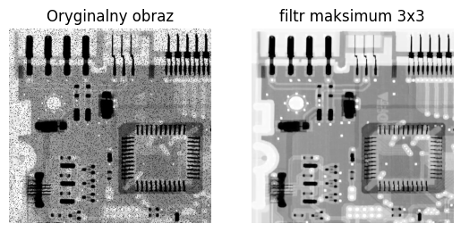

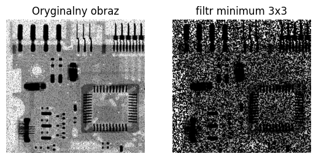

```
cboard_salt_only
```

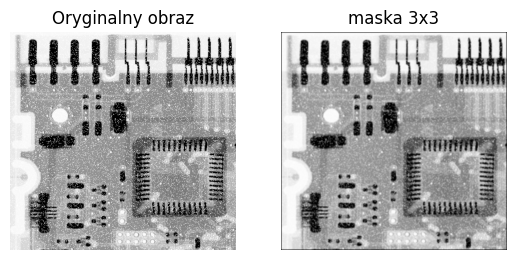

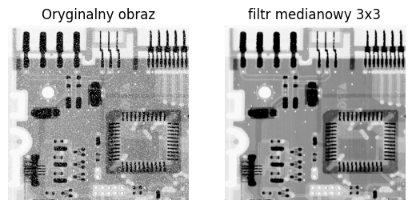

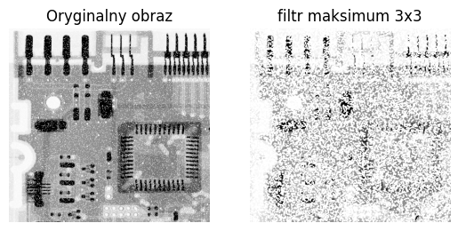

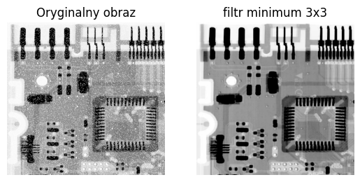

```
cboard_salt_pepper
```

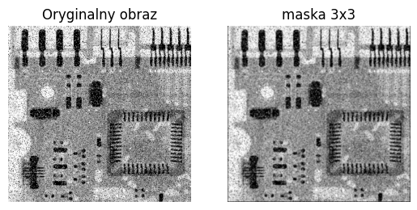

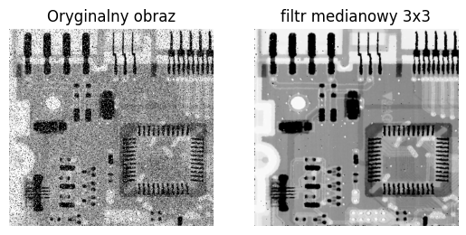

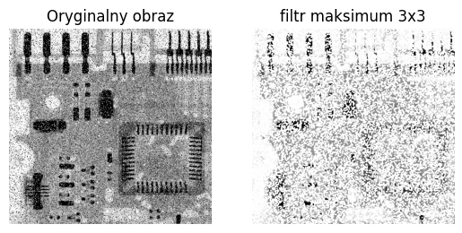

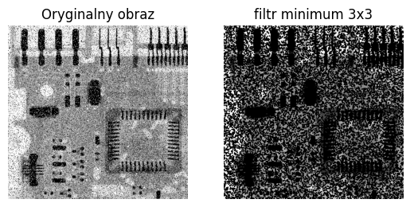

```python
%run functions.ipynb
from ipywidgets import interact
import ipywidgets as widgets
data_path='../data/'
image_extension=".tif"
images=["cboard_pepper_only","cboard_salt_only" ,"cboard_salt_pepper"]
size=3
for image in images:
    image_path=data_path+image+image_extension
    print(image)
    liniowy_filtr(image_path=image_path, k=size)
    filtr_medianowy(image_path=image_path, k=size)
    filtr_maksimum(image_path=image_path, k=size)
    filtr_minimum(image_path=image_path, k=size)
```

**Wnioski:**  
1.Dla obrazu cboard_pepper_salt: Jako, że oryginalny obraz jest zaszumiony szumem "sól-pieprz", wygładzenie go najlepiej działa przy użyciu filtra medianowego (Spośród podanych metod statystycznych użytych w filtrach, mediana jest najmniej czuła na wartości odstające)  
2.Użycie większej maski, sprawia że obraz upadabnia się do siebie lokalnie - powoduje to rozmycie obrazu.  
3.Dla obrazu cboard_pepper_only: zarówno filtr maksimum jak i filtr medianowy pozwalają na poprawienie obrazu - czerń na obrazach jest reprezentowana przez niskie wartości, dlatego uwypuklenie wysokich wartości przy użyciu filtra maksimum pozwala na ucięcie zakłóceń typu "pieprz"  
4.Alternatywnie użycie filtrs minimum dla obrazu cboard_salt_only pozwoli na wycięcie szumów typu "sól".